# Survival_Analysis_GROUP 1

### 1.2 Data Preprocessing

To address the data entry errors identified in the mental health variables, we implement a cleaning process by replacing the erroneous values with their correct categories.

The bar plots showed that the variables were not standardized and contained not only the four expected categories—Not difficult, Somewhat, Very difficult, and Extremely difficult—but also single-letter responses like ‘n’, ‘s’, and ‘e’, as well as NA entries. To standardize the data, we recoded these values as follows:

- `s` and `S` were recoded as “Somewhat”
- `e` and `E` were recoded as “Extremely difficult”
- `n` and `Nof difficult` were recoded as “Not difficult”
- NA values were left unchanged

This cleaning process ensured that the dataset was consistent and ready for accurate analysis.

```r
#recode erroneous entries
mental_health<- mental_health %>%
  mutate(across(everything(), ~recode(.,
                                      'e' = "Extremely difficult",
                                      'E' = "Extremely difficult",
                                      'n' = "Not difficult",
                                      'Nof difficult' = 'Not difficult',
                                      's' = "Somewhat",
                                      'S' = "Somewhat")))
```

After implementing the data cleaning process, the updated bar plots no longer contain the previously identified errors. The variables are now contain only the expected categories: Not difficult, Somewhat, Very difficult, and Extremely difficult. Additionally, NA values remain unchanged

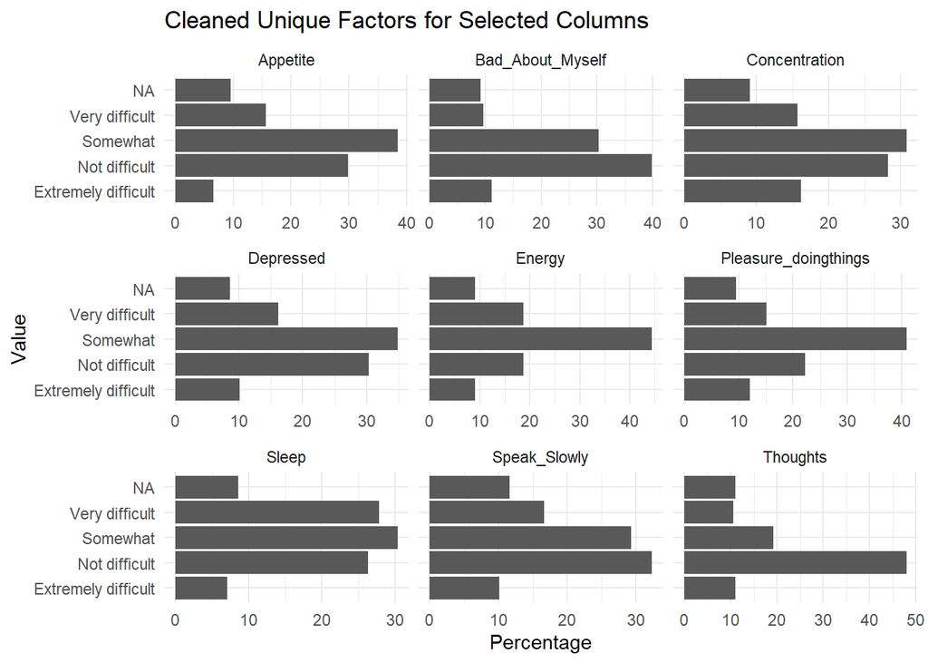

```r
#create dataframe in long format
long_data <- mental_health %>%
  pivot_longer(cols = everything(), names_to = "Variable", values_to = "Value")

#plot barplots
ggplot(long_data, aes(x = Value, y = (..count..)/sum(..count..))) +
  geom_bar(aes(y = ..prop.. * 100, group = 1), stat = "count") +
  facet_wrap(~ Variable, scales = "free_x") +
  theme(axis.text.x = element_text(angle = 90, vjust = 0.5, hjust = 1)) +
  labs(title = "Cleaned Unique Factors for Selected Columns",
       x = "Value",
       y = "Percentage") +
  theme_minimal() + coord_flip()
```

We recoded categorical responses into numerical values to facilitate numerical analysis. Specifically, we converted the responses as follows: `Not difficult` to 0, `Somewhat` to 1, `Very difficult` to 2, and `Extremely difficult` to 3. Any other values were set to NA to ensure the columns remain numeric.

```r
#recode variables
mental_health_recoded <- mental_health %>%
  mutate(across(everything(), ~ case_when(
    . == 'Not difficult' ~ 0,
    . == 'Somewhat' ~ 1,
    . == 'Very difficult' ~ 2,
    . == 'Extremely difficult' ~ 3,
    TRUE ~ NA_real_  # Ensure any other values are set to NA
  )))

#view results
head(mental_health_recoded)
```

```
## # A tibble: 6 × 9
##   Pleasure_doingthings Depressed Sleep Energy Appetite Bad_About_Myself
##                  <dbl>     <dbl> <dbl>  <dbl>    <dbl>            <dbl>
## 1                    1         0     1      1        0                0
## 2                    2         0     0      0        1                0
## 3                    3         2     0      3        0                0
## 4                    1         0     2      2        1                0
## 5                    1         0     2      1        1                2
## 6                    3         1     2      3        1                2
## # ℹ 3 more variables: Concentration <dbl>, Speak_Slowly <dbl>, Thoughts <dbl>
```